# Ejercicios descriptiva

Eudald

21/5/2021

# Ejercicio final

## A. Clasifica las variables de la base de datos, teniendo en cuenta su escala de medida, en variables cualitativas nominales, cualitativas ordinales, cuantitativas discretas o cuantitativas continuas.

ID -> No se usa. BAJOPESO -> Cualitativa nominal. CLASE -> Cualitativa ordinal. EDAD -> Cuantitativa continua. FUMAR -> Cualitativa nominal. VISITAS -> Cuantitativa discreta. PESO -> Cuantitativa continua.

## B. ¿Cuál es la media del peso de los bebés al nacer? y la mediana? y la varianza? y la desviación estándar? y el primer y el tercer cuartil? Valora los resultados.

Media y cuarticles:

```
##    Min. 1st Qu.  Median    Mean 3rd Qu.    Max.
##    1885    2497    3271    3160    3783    4593
```

Varianza:

```
## [1] 615315
```

Desviación estándar

```
## [1] 784.4201
```

## C. Calcula qué porcentaje de madres habían fumado durante el embarazo. ¿Cómo representarías gráficamente este resultado?

```
##
##        No        Sí
## 0.6111111 0.3888889
```

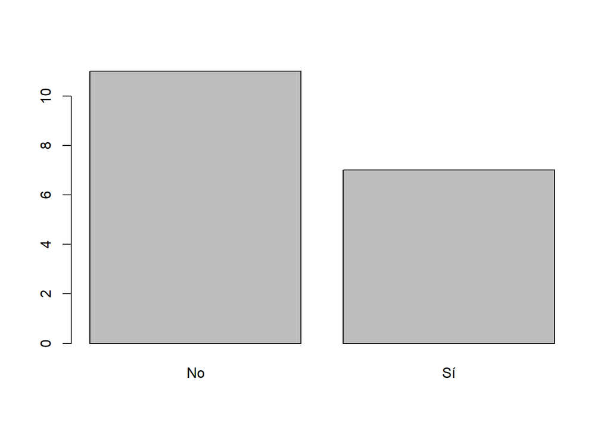

## D. Representa en una tabla de frecuencias el número de visitas a ginecología durante el primer trimestre del embarazo. ¿Cómo representarías gráficamente esta variable? ¿Qué número y porcentaje de madres habían hecho al menos una visita?

```
##
## 0 1 2 3
## 9 5 3 1
```

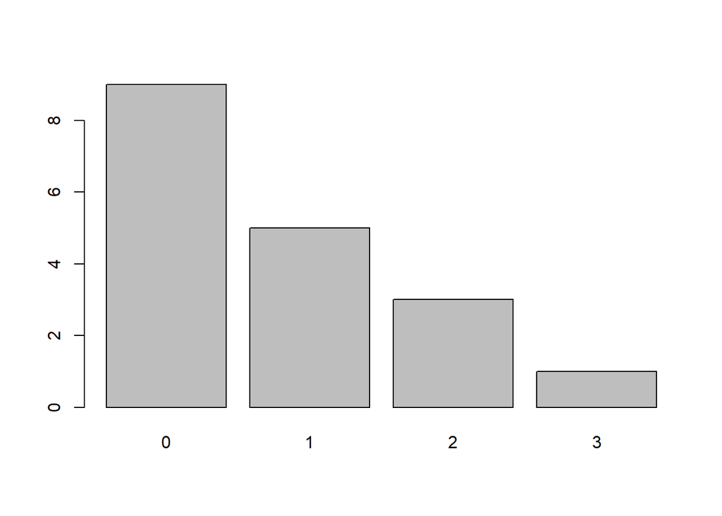

Al menos una visita:

```
## [1] 9
```

En procentage:

[output not shown]

## E. Calcula ahora los mismos estadísticos del apartado B (media del peso del bebé, etc) primero si las madres habían fumado durante el embarazo y luego si las madres habían fumado durante el embarazo. Valoran los resultados.

```
##
##  Descriptive statistics by group
## group: No
##    vars  n    mean     sd median trimmed   mad  min  max range skew kurtosis
## X1    1 11 3460.18 629.73   3402 3446.56 630.1 2450 4593  2143 0.08    -1.04
##        se
## X1 189.87
## ------------------------------------------------------------
## group: Sí
##    vars n    mean     sd median trimmed    mad  min  max range skew kurtosis
## X1    1 7 2689.43 811.73   2296 2689.43 609.35 1885 3856  1971 0.37    -1.84
##        se
## X1 306.81
```

## F. ¿Cómo representarías gráficamente los estadísticos del apartado E? Hazlo y valoran lo que observes.

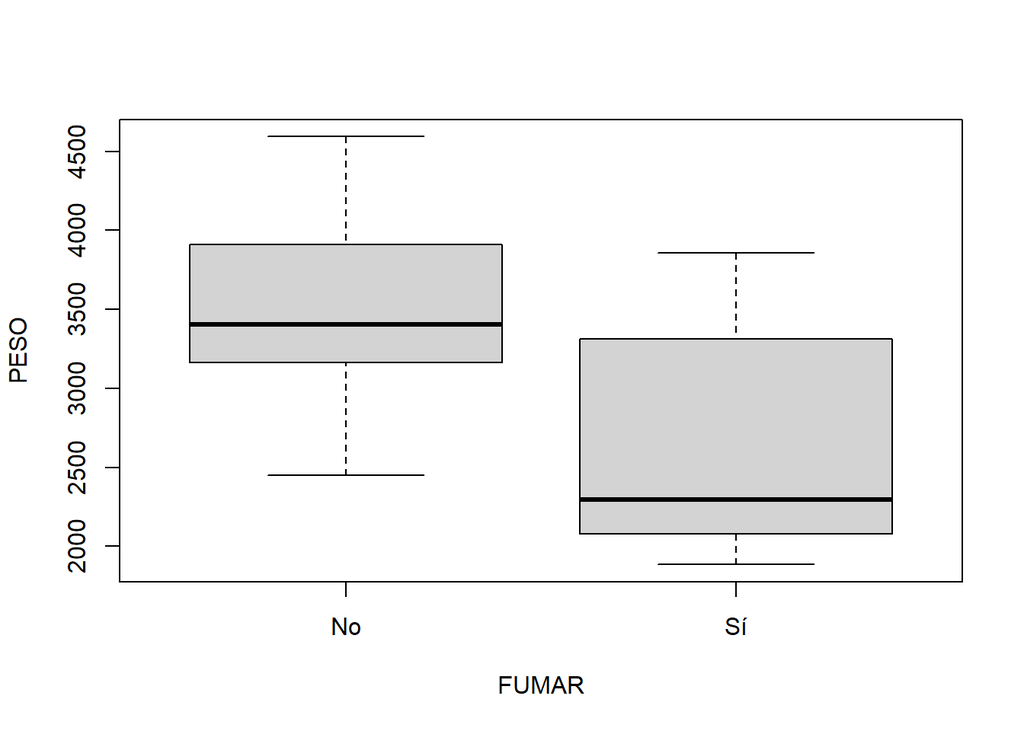